# Proyecto

# Primera parte - R: Vuelos de NYC

Para el cálculo de los promedios de demora en este análisis, se tomó la decisión de filtrar la muestra para incluir únicamente los retrasos efectivos (`delay > 0`). Se descartaron los valores negativos (salidas o llegadas tempranas) para evitar que estos compensaran algebraicamente los retrasos. De esta forma, la métrica resultante no refleja un “balance neto” del sistema, sino la **magnitud real**.

- Cargamos las librerías necesarias y conectamos con SQLite

```r
library(DBI)
library(RSQLite)
library(dplyr)
library(knitr)

con <- dbConnect(RSQLite::SQLite(), "vuelos.db")
# Verificamos que la tabla se cargo correctamente
dbListTables(con)
```

```
[1] "aerolineas"  "aeropuertos" "aviones"     "clima"       "vuelos"
```

- Creamos las referencias de las tablas

```r
aerolineas <- tbl(con, "aerolineas")
aeropuertos <- tbl(con, "aeropuertos")
aviones <- tbl(con, "aviones")
clima <- tbl(con, "clima")
vuelos <- tbl(con, "vuelos")
```

- Observamos que lleva cada tabla.

```r
head(aerolineas)
```

```
# Source:   SQL [?? x 2]
# Database: sqlite 3.51.2 [C:\Users\gadri\Downloads\vuelos.db]
  carrier name
  <chr>   <chr>
1 9E      Endeavor Air Inc.
2 AA      American Airlines Inc.
3 AS      Alaska Airlines Inc.
4 B6      JetBlue Airways
5 DL      Delta Air Lines Inc.
6 EV      ExpressJet Airlines Inc.
```

```r
head(aeropuertos,20)
```

```
# Source:   SQL [?? x 8]
# Database: sqlite 3.51.2 [C:\Users\gadri\Downloads\vuelos.db]
   faa   name                                 lat    lon   alt    tz dst   tzone
   <chr> <chr>                              <dbl>  <dbl> <dbl> <dbl> <chr> <chr>
 1 04G   Lansdowne Airport                   41.1  -80.6  1044    -5 A     Amer…
 2 06A   Moton Field Municipal Airport       32.5  -85.7   264    -6 A     Amer…
 3 06C   Schaumburg Regional                 42.0  -88.1   801    -6 A     Amer…
 4 06N   Randall Airport                     41.4  -74.4   523    -5 A     Amer…
 5 09J   Jekyll Island Airport               31.1  -81.4    11    -5 A     Amer…
 6 0A9   Elizabethton Municipal Airport      36.4  -82.2  1593    -5 A     Amer…
 7 0G6   Williams County Airport             41.5  -84.5   730    -5 A     Amer…
 8 0G7   Finger Lakes Regional Airport       42.9  -76.8   492    -5 A     Amer…
 9 0P2   Shoestring Aviation Airfield        39.8  -76.6  1000    -5 U     Amer…
10 0S9   Jefferson County Intl               48.1 -123.    108    -8 A     Amer…
11 0W3   Harford County Airport              39.6  -76.2   409    -5 A     Amer…
12 10C   Galt Field Airport                  42.4  -88.4   875    -6 U     Amer…
13 17G   Port Bucyrus-Crawford County Airp…  40.8  -83.0  1003    -5 A     Amer…
14 19A   Jackson County Airport              34.2  -83.6   951    -5 U     Amer…
15 1A3   Martin Campbell Field Airport       35.0  -84.3  1789    -5 A     Amer…
16 1B9   Mansfield Municipal                 42.0  -71.2   122    -5 A     Amer…
17 1C9   Frazier Lake Airpark                54.0 -125.    152    -8 A     Amer…
18 1CS   Clow International Airport          41.7  -88.1   670    -6 U     Amer…
19 1G3   Kent State Airport                  41.2  -81.4  1134    -5 A     Amer…
20 1G4   Grand Canyon West Airport           35.9 -114.   4813    -7 A     Amer…
```

```r
head(aviones)
```

```
# Source:   SQL [?? x 9]
# Database: sqlite 3.51.2 [C:\Users\gadri\Downloads\vuelos.db]
  tailnum  year type               manufacturer model engines seats speed engine
  <chr>   <int> <chr>              <chr>        <chr>   <int> <int> <int> <chr>
1 N10156   2004 Fixed wing multi … EMBRAER      EMB-…       2    55    NA Turbo…
2 N102UW   1998 Fixed wing multi … AIRBUS INDU… A320…       2   182    NA Turbo…
3 N103US   1999 Fixed wing multi … AIRBUS INDU… A320…       2   182    NA Turbo…
4 N104UW   1999 Fixed wing multi … AIRBUS INDU… A320…       2   182    NA Turbo…
5 N10575   2002 Fixed wing multi … EMBRAER      EMB-…       2    55    NA Turbo…
6 N105UW   1999 Fixed wing multi … AIRBUS INDU… A320…       2   182    NA Turbo…
```

```r
head(vuelos)
```

```
# Source:   SQL [?? x 19]
# Database: sqlite 3.51.2 [C:\Users\gadri\Downloads\vuelos.db]
   year month   day dep_time sched_dep_time dep_delay arr_time sched_arr_time
  <int> <int> <int>    <int>          <int>     <dbl>    <int>          <int>
1  2013     1     1      517            515         2      830            819
2  2013     1     1      533            529         4      850            830
3  2013     1     1      542            540         2      923            850
4  2013     1     1      544            545        -1     1004           1022
5  2013     1     1      554            600        -6      812            837
6  2013     1     1      554            558        -4      740            728
# ℹ 11 more variables: arr_delay <dbl>, carrier <chr>, flight <int>,
#   tailnum <chr>, origin <chr>, dest <chr>, air_time <dbl>, distance <dbl>,
#   hour <dbl>, minute <dbl>, time_hour <dbl>
```

```r
head(clima)
```

```
# Source:   SQL [?? x 15]
# Database: sqlite 3.51.2 [C:\Users\gadri\Downloads\vuelos.db]
  origin  year month   day  hour  temp  dewp humid wind_dir wind_speed wind_gust
  <chr>  <int> <int> <int> <int> <dbl> <dbl> <dbl>    <dbl>      <dbl>     <dbl>
1 EWR     2013     1     1     1  39.0  26.1  59.4      270      10.4         NA
2 EWR     2013     1     1     2  39.0  27.0  61.6      250       8.06        NA
3 EWR     2013     1     1     3  39.0  28.0  64.4      240      11.5         NA
4 EWR     2013     1     1     4  39.9  28.0  62.2      250      12.7         NA
5 EWR     2013     1     1     5  39.0  28.0  64.4      260      12.7         NA
6 EWR     2013     1     1     6  37.9  28.0  67.2      240      11.5         NA
# ℹ 4 more variables: precip <dbl>, pressure <dbl>, visib <dbl>,
#   time_hour <dbl>
```

## 1.- ¿Qué aerolínea tuvo el mayor retraso promedio en la salida en 2013?

- Con dplyr

```r
pregunta_1_dplyr <- vuelos %>%
  # Filtramos por año 2013 y solo vuelos con retraso efectivo
  filter(year == 2013 & dep_delay > 0) %>%
  group_by(carrier) %>%
  summarise(retraso_promedio = mean(dep_delay, na.rm = TRUE)) %>%
  left_join(aerolineas, by = "carrier") %>%
  arrange(desc(retraso_promedio)) %>%
  select(name, retraso_promedio) %>%
  collect()

# Ver el resultado
head(pregunta_1_dplyr, 1)
```

```
# A tibble: 1 × 2
  name                  retraso_promedio
  <chr>                            <dbl>
1 SkyWest Airlines Inc.               58
```

- Con SQL

```r
query_1_sql <- "
SELECT
    a.name AS aerolinea,
    AVG(f.dep_delay) AS retraso_promedio
  FROM vuelos f
  JOIN aerolineas a ON f.carrier = a.carrier
  WHERE f.year = 2013 AND f.dep_delay > 0
  GROUP BY a.name
  ORDER BY retraso_promedio DESC
  LIMIT 1;
"
pregunta_1_sql <- dbGetQuery(con, query_1_sql)
print(pregunta_1_sql)
```

```
              aerolinea retraso_promedio
1 SkyWest Airlines Inc.               58
```

- Por lo tanto, al filtrar los retrasos siempre mayores que cero, la aerolínea que tuvo mayor retraso promedio de salida en 2013 fue `SkyWest Airlines Inc.`

## 2.- ¿Qué día de la semana tuvo más vuelos retrasados en promedio?

- Con dplyr

```r
#cargamos la paqueteria lubridate para un mejor manejo de fechas

library(lubridate)
```

```r
pregunta_2_dplyr <- vuelos %>%
  # Filtramso solo los vuelos que SÍ tuvieron retraso (mayor a 0 minutos)
  filter(dep_delay > 0) %>%
  # Contar cuántos vuelos retrasados hubo cada día exacto del año
  count(year, month, day, name = "vuelos_retrasados") %>%
  # Traer este resumen a la memoria de R
  collect() %>%
  # Crear una columna de fecha y extraer el día de la semana
  mutate(
    fecha = make_date(year, month, day),
    dia_semana = wday(fecha, label = TRUE, abbr = FALSE)
    # wday() dirá si fue lunes, martes, etc.
  ) %>%
  # Ahora agrupamos por ese día de la semana
  group_by(dia_semana) %>%
  # Calculamos el promedio de vuelos retrasados
  summarise(promedio_retrasos = mean(vuelos_retrasados)) %>%
  # Ordenar de mayor a menor
  arrange(desc(promedio_retrasos))

# Ver el resultado
kable(pregunta_2_dplyr)
```

| dia_semana | promedio_retrasos |
| --- | --- |
| jueves | 403.9808 |
| viernes | 398.4423 |
| lunes | 381.6346 |
| miércoles | 350.1538 |
| martes | 338.6981 |
| domingo | 336.2885 |
| sábado | 254.1346 |

- Con SQL

```r
query_2_sql <- "
  WITH VuelosDiarios AS (
    SELECT
      year,
      month,
      day,
      COUNT(*) AS cantidad_retrasos,
      -- Construimos la fecha (YYYY-MM-DD) y extraemos el número del día de la semana
      strftime('%w', year || '-' || substr('0' || month, -2, 2) || '-' || substr('0' || day, -2, 2)) AS dia_num
    FROM vuelos
    WHERE dep_delay > 0
    GROUP BY year, month, day
  )
  SELECT
    CASE dia_num
      WHEN '0' THEN 'Domingo'
      WHEN '1' THEN 'Lunes'
      WHEN '2' THEN 'Martes'
      WHEN '3' THEN 'Miércoles'
      WHEN '4' THEN 'Jueves'
      WHEN '5' THEN 'Viernes'
      WHEN '6' THEN 'Sábado'
    END AS dia_semana,
    AVG(cantidad_retrasos) AS promedio_retrasos
  FROM VuelosDiarios
  GROUP BY dia_num, dia_semana
  ORDER BY promedio_retrasos DESC;
"

pregunta_2_sql <- dbGetQuery(con, query_2_sql)
kable(pregunta_2_sql)
```

| dia_semana | promedio_retrasos |
| --- | --- |
| Jueves | 403.9808 |
| Viernes | 398.4423 |
| Lunes | 381.6346 |
| Miércoles | 350.1538 |
| Martes | 338.6981 |
| Domingo | 336.2885 |
| Sábado | 254.1346 |

- Por lo tanto, el día con más retrasos promedio es el `JUEVES`

## 3.- ¿Cuál es la distribución de los retrasos en la salida para cada aeropuerto?

- Con dplyr

```r
pregunta_3_dplyr <- vuelos %>%
  # Filtramos solo los retrasos efectivos
  filter(!is.na(dep_delay) & dep_delay > 0) %>%
  group_by(origin) %>%
  summarise(
    total_vuelos_retrasados = n(),
    retraso_promedio = mean(dep_delay, na.rm = TRUE),
    retraso_minimo = min(dep_delay, na.rm = TRUE),
    retraso_maximo = max(dep_delay, na.rm = TRUE)
  ) %>%
  collect()

kable(pregunta_3_dplyr)
```

| origin | total_vuelos_retrasados | retraso_promedio | retraso_minimo | retraso_maximo |
| --- | --- | --- | --- | --- |
| EWR | 52711 | 38.98792 | 1 | 1126 |
| JFK | 42031 | 38.04677 | 1 | 1301 |
| LGA | 33690 | 41.63096 | 1 | 911 |

- Con SQL

```r
query_3_sql <- "
  SELECT
    origin AS aeropuerto_origen,
    COUNT(*) AS total_vuelos_retrasados,
    AVG(dep_delay) AS retraso_promedio,
    MIN(dep_delay) AS retraso_minimo,
    MAX(dep_delay) AS retraso_maximo
  FROM vuelos
  WHERE dep_delay IS NOT NULL AND dep_delay > 0
  GROUP BY origin;
"

pregunta_3_sql <- dbGetQuery(con, query_3_sql)

kable(pregunta_3_sql)
```

| aeropuerto_origen | total_vuelos_retrasados | retraso_promedio | retraso_minimo | retraso_maximo |
| --- | --- | --- | --- | --- |
| EWR | 52711 | 38.98792 | 1 | 1126 |
| JFK | 42031 | 38.04677 | 1 | 1301 |
| LGA | 33690 | 41.63096 | 1 | 911 |

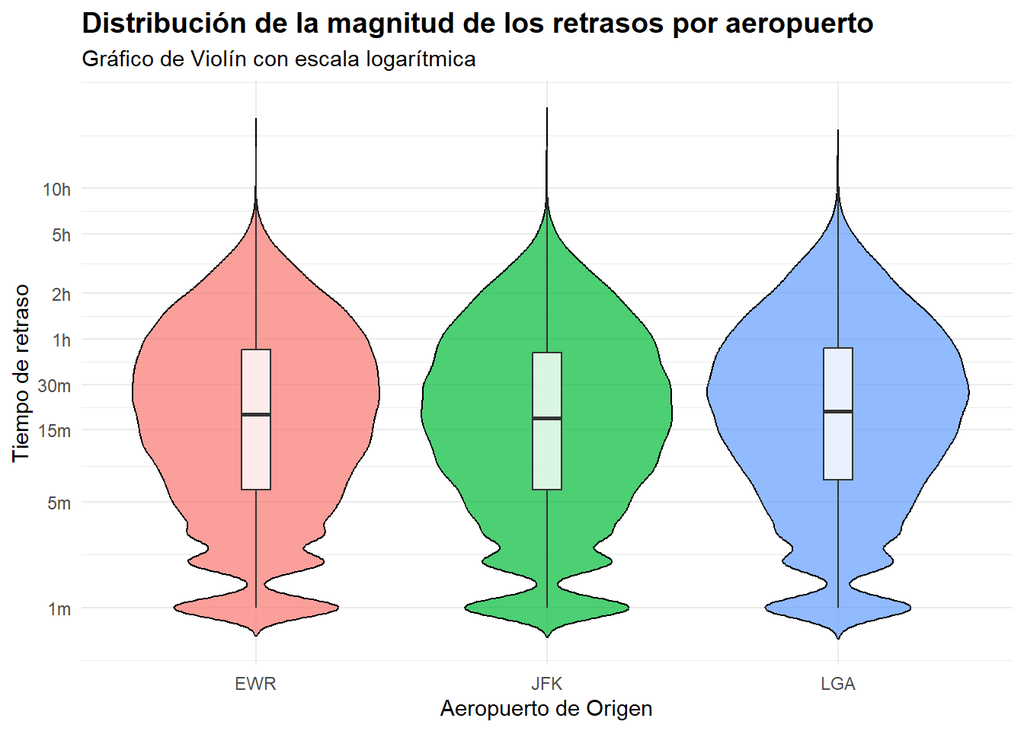

```r
library(ggplot2)

vuelos_retrasados_grafico <- vuelos %>%
  select(origin, dep_delay) %>%
  filter(!is.na(dep_delay) & dep_delay > 0) %>%
  collect()

ggplot(vuelos_retrasados_grafico, aes(x = origin, y = dep_delay, fill = origin)) +
  # Dibujamos el violín
  geom_violin(alpha = 0.7, trim = FALSE, color = "black") +

  # Agregamos un mini-boxplot adentro para ver los cuartiles y la mediana
  geom_boxplot(width = 0.1, fill = "white", alpha = 0.8, outlier.shape = NA) +

  # Aplicamos escala logarítmica al eje Y para que no se aplaste
  scale_y_log10(
    breaks = c(1, 5, 15, 30, 60, 120, 300, 600),
    labels = c("1m", "5m", "15m", "30m", "1h", "2h", "5h", "10h")
  ) +
  labs(
    title = "Distribución de la magnitud de los retrasos por aeropuerto",
    subtitle = "Gráfico de Violín con escala logarítmica",
    x = "Aeropuerto de Origen",
    y = "Tiempo de retraso"
  ) +
  theme_minimal() +
  theme(
    plot.title = element_text(face = "bold", size = 14),
    legend.position = "none"
  )
```

La distribución de los retrasos en los tres aeropuertos presenta una forma similar, caracterizada por una fuerte asimetría positiva. Esto indica que la mayoría de los vuelos presentan retrasos relativamente pequeños (entre aproximadamente 5 y 60 minutos), mientras que existe una cola larga de retrasos extremos, alcanzando valores superiores a varias horas.

Comparando notamos que el aeropuerto LGA muestra el mayor retraso promedio, lo que sugiere un desempeño ligeramente peor. Sin embargo, EWR y JFK presentan distribuciones muy similares.

La gráfica de violín revela que la densidad de los retrasos está concentrada en valores bajos, pero con una dispersión considerable en los tres aeropuertos. Además, los valores máximos observados evidencian la presencia de eventos extremos que afectan significativamente la variabilidad.

Finalmente, aunque existen diferencias en el promedio, la forma general de las distribuciones sugiere que los tres aeropuertos comparten patrones operativos similares, con variaciones moderadas en la magnitud de los retrasos.

## 4.- ¿Qué proporción de vuelos se retrasaron más de 30 minutos?

- Con dplyr

```r
pregunta_4_dplyr <- vuelos %>%
  # Quitamos los vuelos cancelados (nulos) para no afectar la proporción
  filter(!is.na(dep_delay)) %>%
  summarise(
    # Contamos el total de vuelos que sí salieron
    total_vuelos = n(),
    # Sumamos 1 si se retrasó más de 30 min, y 0 si no
    vuelos_retrasados = sum(ifelse(dep_delay > 30, 1, 0), na.rm = TRUE)
  ) %>%
  # Calculamos la proporción y el porcentaje
  mutate(
    proporcion = vuelos_retrasados / total_vuelos,
    porcentaje = (vuelos_retrasados / total_vuelos) * 100
  ) %>%
  collect()

# Ver el resultado
kable(pregunta_4_dplyr)
```

| total_vuelos | vuelos_retrasados | proporcion | porcentaje |
| --- | --- | --- | --- |
| 328521 | 48291 | 0.1469952 | 14.69952 |

- Con SQL

```r
query_4_sql <- "
  SELECT
    COUNT(dep_delay) AS total_vuelos,
    SUM(CASE WHEN dep_delay > 30 THEN 1 ELSE 0 END) AS vuelos_retrasados,
    -- Multiplicamos por 1.0 para forzar que el resultado tenga decimales
    (SUM(CASE WHEN dep_delay > 30 THEN 1 ELSE 0 END) * 1.0) / COUNT(dep_delay) AS proporcion,
    ((SUM(CASE WHEN dep_delay > 30 THEN 1 ELSE 0 END) * 1.0) / COUNT(dep_delay)) * 100 AS porcentaje
  FROM vuelos
  WHERE dep_delay IS NOT NULL;
"

pregunta_4_sql <- dbGetQuery(con, query_4_sql)

# Ver el resultado
kable(pregunta_4_sql)
```

| total_vuelos | vuelos_retrasados | proporcion | porcentaje |
| --- | --- | --- | --- |
| 328521 | 48291 | 0.1469952 | 14.69952 |

Tras excluir los vuelos cancelados (valores nulos en la variable de retraso), tal que, una proporción de 0.147 de lso vuelos tuvieron un retraso de 30 minutos o más, indicando que casi 15 de 100 vuelos salen retrasados por 30 minutos o más.

## 5.- ¿Qué destinos tuvieron los mayores retrasos promedio en la llegada?

- Con dplyr

```r
pregunta_5_dplyr <- vuelos %>%
  # Filtramos llegadas tempranas, aislando solo los retrasos reales
  filter(!is.na(arr_delay) & arr_delay > 0) %>%
  group_by(dest) %>%
  summarise(
    retraso_prom_llegada = mean(arr_delay, na.rm = TRUE),
    total_vuelos = n()
  ) %>%
  left_join(aeropuertos, by = c("dest" = "faa")) %>%
  arrange(desc(retraso_prom_llegada)) %>%
  select(dest, name, retraso_prom_llegada, total_vuelos) %>%
  head(10) %>%
  collect()

kable(pregunta_5_dplyr)
```

| dest | name | retraso_prom_llegada | total_vuelos |
| --- | --- | --- | --- |
| TVC | Cherry Capital Airport | 66.68571 | 35 |
| TUL | Tulsa Intl | 60.37306 | 193 |
| BHM | Birmingham Intl | 60.05785 | 121 |
| TYS | Mc Ghee Tyson | 59.86645 | 307 |
| DSM | Des Moines Intl | 57.02692 | 260 |
| OKC | Will Rogers World | 56.56219 | 201 |
| CAE | Columbia Metropolitan | 53.63218 | 87 |
| RIC | Richmond Intl | 53.33027 | 1196 |
| MSN | Dane Co Rgnl Truax Fld | 52.77193 | 285 |
| CVG | Cincinnati Northern Kentucky Intl | 52.37917 | 1680 |

- Con SQL

```r
query_5_sql <- "
  SELECT
    v.dest AS codigo_destino,
    a.name AS nombre_aeropuerto,
    AVG(v.arr_delay) AS retraso_prom_llegada,
    COUNT(*) AS total_vuelos
  FROM vuelos v
  LEFT JOIN aeropuertos a ON v.dest = a.faa
  WHERE v.arr_delay > 0
  GROUP BY v.dest, a.name
  ORDER BY retraso_prom_llegada DESC
  LIMIT 10;
"

pregunta_5_sql <- dbGetQuery(con, query_5_sql)
kable(pregunta_5_sql)
```

| codigo_destino | nombre_aeropuerto | retraso_prom_llegada | total_vuelos |
| --- | --- | --- | --- |
| TVC | Cherry Capital Airport | 66.68571 | 35 |
| TUL | Tulsa Intl | 60.37306 | 193 |
| BHM | Birmingham Intl | 60.05785 | 121 |
| TYS | Mc Ghee Tyson | 59.86645 | 307 |
| DSM | Des Moines Intl | 57.02692 | 260 |
| OKC | Will Rogers World | 56.56219 | 201 |
| CAE | Columbia Metropolitan | 53.63218 | 87 |
| RIC | Richmond Intl | 53.33027 | 1196 |
| MSN | Dane Co Rgnl Truax Fld | 52.77193 | 285 |
| CVG | Cincinnati Northern Kentucky Intl | 52.37917 | 1680 |

Por lo tanto, los destinos con mayor retraso promedio fue `Cherry Capital Airport`, `Tulsan Intl` y `Birmingham Intl`, también nos damos cuenta que la mayoría de estos destinos tienen pocos vuelos, lo que hace que su promedio sea más sensible a valores altos de retrasos.

## 6.- ¿Qué aerolíneas tuvieron el mayor número de vuelos desde NYC?

- Con dplyr

```r
pregunta_6_dplyr <- vuelos %>%
  #Agrupar por codigo de aerolinea
  group_by(carrier) %>%
  #Contar el total de vuelos de cada uno
  summarise(total_vuelos=n()) %>%
  #Unir con la tabla aerolineas para traer el nombre real
  left_join(aerolineas, by= "carrier") %>%
  #Ordenamos de mayor a menor
  arrange(desc(total_vuelos)) %>%
  #Limpiar la salida seleccionando solo las columnas de interes
  select(name, total_vuelos) %>%
  head(10) %>%
  collect()

kable(pregunta_6_dplyr)
```

| name | total_vuelos |
| --- | --- |
| United Air Lines Inc. | 58665 |
| JetBlue Airways | 54635 |
| ExpressJet Airlines Inc. | 54173 |
| Delta Air Lines Inc. | 48110 |
| American Airlines Inc. | 32729 |
| Envoy Air | 26397 |
| US Airways Inc. | 20536 |
| Endeavor Air Inc. | 18460 |
| Southwest Airlines Co. | 12275 |
| Virgin America | 5162 |

- Con SQL

```r
query_6_sql <- "
  SELECT
    a.name AS aerolinea,
    COUNT(*) AS total_vuelos
  FROM vuelos v
  JOIN aerolineas a ON v.carrier = a.carrier
  GROUP BY a.name
  ORDER BY total_vuelos DESC
  LIMIT 10;
  "
pregunta_6_sql <- dbGetQuery(con, query_6_sql)

# Mostrar el resultado
kable(pregunta_6_sql)
```

| aerolinea | total_vuelos |
| --- | --- |
| United Air Lines Inc. | 58665 |
| JetBlue Airways | 54635 |
| ExpressJet Airlines Inc. | 54173 |
| Delta Air Lines Inc. | 48110 |
| American Airlines Inc. | 32729 |
| Envoy Air | 26397 |
| US Airways Inc. | 20536 |
| Endeavor Air Inc. | 18460 |
| Southwest Airlines Co. | 12275 |
| Virgin America | 5162 |

Por lo que las aerolíneas que tienen el mayor numero de vuelos desde NYC son `United Air Lines Inc`, `JetBlue Airways` y `ExpressJet Airlines Inc`.

## 7.- ¿Cómo varía el retraso de los vuelos según el fabricante de la aeronave?

- Con dplyr

```r
pregunta_7_dplyr <- vuelos %>%
  inner_join(aviones, by="tailnum") %>%
  # Filtramos solo retrasos efectivos
  filter(!is.na(manufacturer) & !is.na(dep_delay) & dep_delay > 0) %>%
  group_by(manufacturer) %>%
  summarise(
    retraso_prom = mean(dep_delay, na.rm=TRUE),
    total_vuelos = n()
  ) %>%
  arrange(desc(retraso_prom)) %>%
  head(10) %>%
  collect()

kable(pregunta_7_dplyr)
```

| manufacturer | retraso_prom | total_vuelos |
| --- | --- | --- |
| AVIAT AIRCRAFT INC | 84.20000 | 5 |
| FRIEDEMANN JON | 67.90476 | 21 |
| LAMBERT RICHARD | 61.23529 | 17 |
| CANADAIR | 58.18310 | 568 |
| AGUSTA SPA | 58.00000 | 18 |
| BELL | 57.05000 | 20 |
| HURLEY JAMES LARRY | 53.33333 | 3 |
| BOMBARDIER INC | 51.08288 | 11148 |
| MCDONNELL DOUGLAS CORPORATION | 49.46193 | 394 |
| LEBLANC GLENN T | 48.42857 | 7 |

- Con SQL

```r
query_7_sql <- "
  SELECT
    a.manufacturer AS fabricante,
    AVG(v.dep_delay) AS retraso_promedio,
    COUNT(*) AS total_vuelos_retrasados
  FROM vuelos v
  JOIN aviones a ON v.tailnum = a.tailnum
  WHERE a.manufacturer IS NOT NULL AND v.dep_delay > 0
  GROUP BY a.manufacturer
  ORDER BY retraso_promedio DESC
  LIMIT 10;
"

pregunta_7_sql <- dbGetQuery(con, query_7_sql)
kable(pregunta_7_sql)
```

| fabricante | retraso_promedio | total_vuelos_retrasados |
| --- | --- | --- |
| AVIAT AIRCRAFT INC | 84.20000 | 5 |
| FRIEDEMANN JON | 67.90476 | 21 |
| LAMBERT RICHARD | 61.23529 | 17 |
| CANADAIR | 58.18310 | 568 |
| AGUSTA SPA | 58.00000 | 18 |
| BELL | 57.05000 | 20 |
| HURLEY JAMES LARRY | 53.33333 | 3 |
| BOMBARDIER INC | 51.08288 | 11148 |
| MCDONNELL DOUGLAS CORPORATION | 49.46193 | 394 |
| LEBLANC GLENN T | 48.42857 | 7 |

En los primeros lugares se encuentran fabricantes como`AVIAT AIRCRAFT INC`, `FRIEDEMANN JON` los cuales registran los retrasos promedio más altos . Sin embargo, al observar la columna total_vuelos, notamos que tienen pocos vuelos . Por lo que el promedio es muy sensible, bastan un par de vuelos con retrasos altos para inflar el promedio de todo el fabricante.

La “variación” extrema en la cima de la tabla no es un indicador de que los aviones de ciertos fabricantes sean más propensos a retrasarse, sino un reflejo de promedios calculados sobre muestras muy pequeñas. Para los aviones con más vuelos, los retrasos tienden a estabilizarse.

## 8.- ¿Los aviones más antiguos tienen más retrasos?

- Con dplyr

```r
pregunta_8_dplyr <- vuelos %>%
  inner_join(aviones, by = "tailnum", suffix = c("_vuelo", "_fabricacion")) %>%
  # Filtramos solo retrasos reales
  filter(!is.na(year_fabricacion) & !is.na(dep_delay) & dep_delay > 0) %>%
  group_by(year_fabricacion) %>%
  summarise(
    retraso_promedio = mean(dep_delay, na.rm = TRUE),
    total_vuelos = n()
  ) %>%
  arrange(year_fabricacion) %>%
  head(10) %>%
  collect()

kable(pregunta_8_dplyr)
```

| year_fabricacion | retraso_promedio | total_vuelos |
| --- | --- | --- |
| 1956 | 14.90909 | 11 |
| 1959 | 49.87500 | 32 |
| 1963 | 31.55556 | 18 |
| 1965 | 5.00000 | 1 |
| 1967 | 36.75000 | 8 |
| 1968 | 75.62500 | 8 |
| 1972 | 41.90909 | 11 |
| 1973 | 10.50000 | 14 |
| 1974 | 36.21212 | 33 |
| 1975 | 45.21212 | 33 |

- Con SQL

```r
query_8_sql <- "
  SELECT
    a.year AS anio_fabricacion,
    AVG(v.dep_delay) AS retraso_promedio,
    COUNT(*) AS total_vuelos_retrasados
  FROM vuelos v
  JOIN aviones a ON v.tailnum = a.tailnum
  WHERE a.year IS NOT NULL AND v.dep_delay > 0
  GROUP BY a.year
  ORDER BY a.year ASC
  LIMIT 10;
"
pregunta_8_sql <- dbGetQuery(con, query_8_sql)
kable(pregunta_8_sql)
```

| anio_fabricacion | retraso_promedio | total_vuelos_retrasados |
| --- | --- | --- |
| 1956 | 14.90909 | 11 |
| 1959 | 49.87500 | 32 |
| 1963 | 31.55556 | 18 |
| 1965 | 5.00000 | 1 |
| 1967 | 36.75000 | 8 |
| 1968 | 75.62500 | 8 |
| 1972 | 41.90909 | 11 |
| 1973 | 10.50000 | 14 |
| 1974 | 36.21212 | 33 |
| 1975 | 45.21212 | 33 |

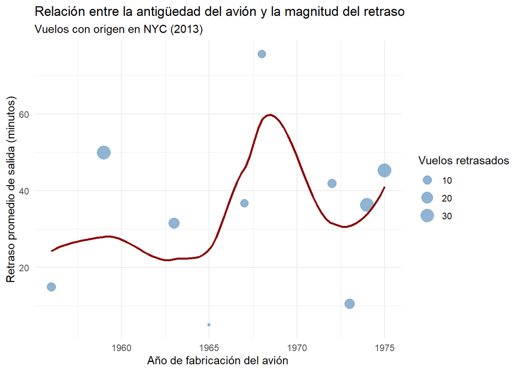

```r
ggplot(pregunta_8_dplyr, aes(x = year_fabricacion, y = retraso_promedio)) +
  geom_point(aes(size = total_vuelos), alpha = 0.6, color = "steelblue") +
  geom_smooth(method = "loess", color = "darkred", se = FALSE) +
  labs(
    title = "Relación entre la antigüedad del avión y la magnitud del retraso",
    subtitle = "Vuelos con origen en NYC (2013) ",
    x = "Año de fabricación del avión",
    y = "Retraso promedio de salida (minutos)",
    size = "Vuelos retrasados"
  ) +
  theme_minimal()
```

```r
correlacion <- cor(
  pregunta_8_dplyr$year_fabricacion,
  pregunta_8_dplyr$retraso_promedio,
  use = "complete.obs"
)
print(paste("El coeficiente de correlación es:", round(correlacion, 4)))
```

```
[1] "El coeficiente de correlación es: 0.1591"
```

Este resultado indica una correlación casi de cero. lo que nos indicaría que el año de fabricación no es importante para los retrasos, existen retrasos para aviones más nuevos y viejos, pero su año de fabricación no es un factor de peso para que se retrasen los vuelos.

## 9.- ¿Qué modelos de aviones se utilizan con mayor frecuencia en vuelos desde NYC?

- Con dplyr

```r
pregunta_9_dplyr <- vuelos %>%
  # Unimos con la tabla de aviones
  inner_join(aviones, by = "tailnum") %>%
  # Agrupamos por el modelo del avión
  group_by(model) %>%
  # Contamos la cantidad de vuelos por modelo
  summarise(frecuencia_vuelos = n()) %>%
  # Filtramos por si hay modelos nulos en el registro
  filter(!is.na(model)) %>%
  # Ordenamos de mayor a menor para tener los más frecuentes arriba
  arrange(desc(frecuencia_vuelos)) %>%
  head(10) %>%
  collect()

kable(pregunta_9_dplyr)
```

| model | frecuencia_vuelos |
| --- | --- |
| A320-232 | 45831 |
| EMB-145LR | 28027 |
| ERJ 190-100 IGW | 23716 |
| EMB-145XR | 14051 |
| 737-824 | 13809 |
| CL-600-2D24 | 11807 |
| 737-7H4 | 10389 |
| MD-88 | 10191 |
| A319-114 | 9713 |
| CL-600-2B19 | 9588 |

- Con SQL

```r
query_9_sql <- "
  SELECT
    a.model AS modelo_avion,
    COUNT(*) AS frecuencia_vuelos
  FROM vuelos v
  JOIN aviones a ON v.tailnum = a.tailnum
  WHERE a.model IS NOT NULL
  GROUP BY a.model
  ORDER BY frecuencia_vuelos DESC
  LIMIT 10;
"

pregunta_9_sql <- dbGetQuery(con, query_9_sql)

kable(pregunta_9_sql)
```

| modelo_avion | frecuencia_vuelos |
| --- | --- |
| A320-232 | 45831 |
| EMB-145LR | 28027 |
| ERJ 190-100 IGW | 23716 |
| EMB-145XR | 14051 |
| 737-824 | 13809 |
| CL-600-2D24 | 11807 |
| 737-7H4 | 10389 |
| MD-88 | 10191 |
| A319-114 | 9713 |
| CL-600-2B19 | 9588 |

Por lo que, los modelos de aviones con mayor frecuencia son: `A320-232`, `EMB-145LR` y `ERJ 190-100 IGW`.

## 10.- ¿Cuál es la distancia promedio de vuelo por aerolínea?

- Con dplyr

```r
pregunta_10_dplyr <- vuelos %>%
  # Agrupamos por el código de la aerolínea
  group_by(carrier) %>%
  # Calculamos la distancia promedio (ignorando vuelos cancelados/sin registro)
  summarise(distancia_promedio = mean(distance, na.rm = TRUE)) %>%
  # Unimos con la tabla de aerolíneas para traer el nombre
  left_join(aerolineas, by = "carrier") %>%
  # Ordenamos de la que vuela más lejos a la que hace vuelos más cortos
  arrange(desc(distancia_promedio)) %>%
  # Limpiamos la salida seleccionando solo nombre y distancia
  select(name, distancia_promedio) %>%
  collect()

kable(pregunta_10_dplyr)
```

| name | distancia_promedio |
| --- | --- |
| Hawaiian Airlines Inc. | 4983.0000 |
| Virgin America | 2499.4822 |
| Alaska Airlines Inc. | 2402.0000 |
| Frontier Airlines Inc. | 1620.0000 |
| United Air Lines Inc. | 1529.1149 |
| American Airlines Inc. | 1340.2360 |
| Delta Air Lines Inc. | 1236.9012 |
| JetBlue Airways | 1068.6215 |
| Southwest Airlines Co. | 996.2691 |
| AirTran Airways Corporation | 664.8294 |
| Envoy Air | 569.5327 |
| ExpressJet Airlines Inc. | 562.9917 |
| US Airways Inc. | 553.4563 |
| Endeavor Air Inc. | 530.2358 |
| SkyWest Airlines Inc. | 500.8125 |
| Mesa Airlines Inc. | 375.0333 |

- Con SQL

```r
query_10_sql <- "
  SELECT
    a.name AS aerolinea,
    AVG(v.distance) AS distancia_promedio
  FROM vuelos v
  JOIN aerolineas a ON v.carrier = a.carrier
  GROUP BY a.name
  ORDER BY distancia_promedio DESC;
"
pregunta_10_sql <- dbGetQuery(con, query_10_sql)


kable(pregunta_10_sql)
```

| aerolinea | distancia_promedio |
| --- | --- |
| Hawaiian Airlines Inc. | 4983.0000 |
| Virgin America | 2499.4822 |
| Alaska Airlines Inc. | 2402.0000 |
| Frontier Airlines Inc. | 1620.0000 |
| United Air Lines Inc. | 1529.1149 |
| American Airlines Inc. | 1340.2360 |
| Delta Air Lines Inc. | 1236.9012 |
| JetBlue Airways | 1068.6215 |
| Southwest Airlines Co. | 996.2691 |
| AirTran Airways Corporation | 664.8294 |
| Envoy Air | 569.5327 |
| ExpressJet Airlines Inc. | 562.9917 |
| US Airways Inc. | 553.4563 |
| Endeavor Air Inc. | 530.2358 |
| SkyWest Airlines Inc. | 500.8125 |
| Mesa Airlines Inc. | 375.0333 |

En el primer lugar destaca `Hawaiian Airlines`, con una distancia promedio cercana a las 5,000 millas. Esto es completamente congruente con su logística, ya que sus rutas desde Nueva York consisten en vuelos directos o de largo alcance hacia Hawái.

## 11.- ¿Qué aeropuerto de NYC tuvo el mayor número de retrasos en la salida?

- Con dplyr

```r
pregunta_11_dplyr <- vuelos %>%
  # Filtrar solo los vuelos que tuvieron un retraso mayor a 0 minutos
  filter(dep_delay > 0) %>%
  # Agrupar por el aeropuerto de origen
  group_by(origin) %>%
  # Contar cuántos vuelos retrasados hay por aeropuerto
  summarise(numero_retrasos = n()) %>%
  # Unir con la tabla aeropuertos para traer el nombre completo (faa es el código)
  left_join(aeropuertos, by = c("origin" = "faa")) %>%
  # Ordenar de mayor a menor
  arrange(desc(numero_retrasos)) %>%
  # Seleccionar las columnas relevantes
  select(origin, name, numero_retrasos) %>%
  collect()

kable(pregunta_11_dplyr)
```

| origin | name | numero_retrasos |
| --- | --- | --- |
| EWR | Newark Liberty Intl | 52711 |
| JFK | John F Kennedy Intl | 42031 |
| LGA | La Guardia | 33690 |

- Con SQL

```r
query_11_sql <- "
  SELECT
    v.origin AS codigo_aeropuerto,
    a.name AS nombre_aeropuerto,
    COUNT(*) AS numero_retrasos
  FROM vuelos v
  JOIN aeropuertos a ON v.origin = a.faa
  WHERE v.dep_delay > 0
  GROUP BY v.origin, a.name
  ORDER BY numero_retrasos DESC;
"

pregunta_11_sql <- dbGetQuery(con, query_11_sql)


kable(pregunta_11_sql)
```

| codigo_aeropuerto | nombre_aeropuerto | numero_retrasos |
| --- | --- | --- |
| EWR | Newark Liberty Intl | 52711 |
| JFK | John F Kennedy Intl | 42031 |
| LGA | La Guardia | 33690 |

Por lo tanto, el aeropuerto `Newark Liberty Intl (EWR)` es la terminal con el mayor número de retrasos registrando un total de `52711` retrasos.

## 12.- ¿Qué aeropuerto tuvo el menor tiempo promedio de taxi-out?

```r
dbListFields(con, "vuelos")
```

```
 [1] "year"           "month"          "day"            "dep_time"
 [5] "sched_dep_time" "dep_delay"      "arr_time"       "sched_arr_time"
 [9] "arr_delay"      "carrier"        "flight"         "tailnum"
[13] "origin"         "dest"           "air_time"       "distance"
[17] "hour"           "minute"         "time_hour"
```

Utilizaremos el proxy taxi_out = (arr_time - dep_time) - air_time. El único detalle es que captura taxi-out + taxi-in juntos (tiempo en tierra antes de despegar y después de aterrizar), no solo el taxi-out puro. Pero es el proxy más honesto posible con las columnas disponibles.

- Con dplyr

```r
pregunta_12_dplyr <- vuelos %>%
  filter(
    !is.na(arr_time) & !is.na(dep_time) & !is.na(air_time)
  ) %>%
  collect() %>%
  mutate(
    # Convertimos arr_time y dep_time de HHMM a minutos desde medianoche
    arr_min  = (arr_time %/% 100) * 60 + (arr_time %% 100),
    dep_min  = (dep_time %/% 100) * 60 + (dep_time %% 100),
    # Corregimos vuelos que cruzan medianoche (arr_min < dep_min)
    arr_min  = ifelse(arr_min < dep_min, arr_min + 1440, arr_min),
    # Proxy: tiempo total de puerta a puerta menos tiempo en el aire
    taxi_total = (arr_min - dep_min) - air_time
  ) %>%
  # Filtramos anomalías: valores negativos o extremos (> 120 min)
  filter(taxi_total > 0 & taxi_total < 120) %>%
  group_by(origin) %>%
  summarise(
    taxi_total_promedio = round(mean(taxi_total, na.rm = TRUE), 2),
    total_vuelos        = n()
  ) %>%
  left_join(collect(aeropuertos), by = c("origin" = "faa")) %>%
  arrange(taxi_total_promedio) %>%
  select(name, taxi_total_promedio, total_vuelos)

kable(pregunta_12_dplyr)
```

| name | taxi_total_promedio | total_vuelos |
| --- | --- | --- |
| Newark Liberty Intl | 27.31 | 64709 |
| La Guardia | 32.98 | 66619 |
| John F Kennedy Intl | 33.38 | 65144 |

- Con SQL

```r
# Con SQL
query_12_sql <- "
  SELECT
    a.name AS aeropuerto,
    ROUND(AVG(
      -- arr_time y dep_time de HHMM a minutos
      ((v.arr_time / 100) * 60 + (v.arr_time % 100))
      -- Ajuste por cruce de medianoche: si arr < dep sumamos 1440
      + CASE
          WHEN ((v.arr_time / 100) * 60 + (v.arr_time % 100)) <
               ((v.dep_time / 100) * 60 + (v.dep_time % 100))
          THEN 1440 ELSE 0
        END
      - ((v.dep_time / 100) * 60 + (v.dep_time % 100))
      -- Restamos el tiempo en el aire
      - v.air_time
    ), 2) AS taxi_total_promedio,
    COUNT(*) AS total_vuelos
  FROM vuelos v
  JOIN aeropuertos a ON v.origin = a.faa
  WHERE
    v.arr_time  IS NOT NULL AND
    v.dep_time  IS NOT NULL AND
    v.air_time  IS NOT NULL AND
    -- Filtramos anomalías directamente en SQL
    (
      ((v.arr_time / 100) * 60 + (v.arr_time % 100))
      + CASE
          WHEN ((v.arr_time / 100) * 60 + (v.arr_time % 100)) <
               ((v.dep_time / 100) * 60 + (v.dep_time % 100))
          THEN 1440 ELSE 0
        END
      - ((v.dep_time / 100) * 60 + (v.dep_time % 100))
      - v.air_time
    ) > 0
    AND
    (
      ((v.arr_time / 100) * 60 + (v.arr_time % 100))
      + CASE
          WHEN ((v.arr_time / 100) * 60 + (v.arr_time % 100)) <
               ((v.dep_time / 100) * 60 + (v.dep_time % 100))
          THEN 1440 ELSE 0
        END
      - ((v.dep_time / 100) * 60 + (v.dep_time % 100))
      - v.air_time
    ) < 120
  GROUP BY v.origin, a.name
  ORDER BY taxi_total_promedio ASC;
"

pregunta_12_sql <- dbGetQuery(con, query_12_sql)
kable(pregunta_12_sql)
```

| aeropuerto | taxi_total_promedio | total_vuelos |
| --- | --- | --- |
| Newark Liberty Intl | 27.31 | 64709 |
| La Guardia | 32.98 | 66619 |
| John F Kennedy Intl | 33.38 | 65144 |

Para estimar el tiempo de taxi-out, se construyó el proxy (arr_time − dep_time) − air_time, que representa el tiempo total de puerta a puerta menos el tiempo efectivo en el aire. Esta diferencia captura el tiempo combinado de rodaje antes del despegue y después del aterrizaje (taxi-out + taxi-in), siendo el estimador más preciso posible con las variables disponibles en el dataset.

## 13.- ¿Qué porcentaje de vuelos que salen de cada aeropuerto de NYC fueron puntuales?

- Con dplyr

```r
pregunta_13_dplyr <- vuelos %>%
  # Excluimos los vuelos cancelados
  filter(!is.na(dep_delay)) %>%
  # Agrupamos por aeropuerto de origen (origin) en lugar de carrier
  group_by(origin) %>%
  summarise(
    total_vuelos = n(),
    vuelos_puntuales = sum(ifelse(dep_delay <= 0, 1, 0), na.rm = TRUE)
  ) %>%
  mutate(porcentaje_puntual = (vuelos_puntuales / total_vuelos) * 100) %>%
  # Unimos con la tabla aeropuertos
  left_join(aeropuertos, by = c("origin" = "faa")) %>%
  arrange(desc(porcentaje_puntual)) %>%
  select(name, porcentaje_puntual, total_vuelos) %>%
  collect()

kable(pregunta_13_dplyr)
```

| name | porcentaje_puntual | total_vuelos |
| --- | --- | --- |
| La Guardia | 66.81082 | 101509 |
| John F Kennedy Intl | 61.58606 | 109416 |
| Newark Liberty Intl | 55.17620 | 117596 |

- Con SQL

```r
query_13_sql <- "
SELECT
  a.name AS aeropuerto,
  COUNT(*) AS total_vuelos,
  SUM(CASE WHEN v.dep_delay <= 0 THEN 1 ELSE 0 END) AS vuelos_puntuales,
  (SUM(CASE WHEN v.dep_delay <= 0 THEN 1 ELSE 0 END) * 100.0) / COUNT(*) AS porcentaje_puntual
FROM vuelos v
-- Unimos con aeropuertos usando origin
JOIN aeropuertos a ON v.origin = a.faa
WHERE v.dep_delay IS NOT NULL
GROUP BY v.origin, a.name
ORDER BY porcentaje_puntual DESC;
"
pregunta_13_sql <- dbGetQuery(con, query_13_sql)
kable(pregunta_13_sql)
```

| aeropuerto | total_vuelos | vuelos_puntuales | porcentaje_puntual |
| --- | --- | --- | --- |
| La Guardia | 101509 | 67819 | 66.81082 |
| John F Kennedy Intl | 109416 | 67385 | 61.58606 |
| Newark Liberty Intl | 117596 | 64885 | 55.17620 |

LaGuardia (LGA) destaca como el aeropuerto más puntual de los tres, logrando sacar a tiempo un mayor porcentaje de sus vuelos. Por el contrario, Newark (EWR) se queda en el último lugar, confirmando que es la terminal donde los pasajeros tienen mayor probabilidad de sufrir un retraso.

## 14.- ¿Qué aeropuertos de destino tienen el mayor retraso promedio en la llegada para vuelos desde NYC?

- Con dplyr

```r
pregunta_14_dplyr <- vuelos %>%
  # Filtramos llegadas reales
  filter(!is.na(arr_delay) & arr_delay > 0) %>%
  group_by(dest) %>%
  summarise(
    retraso_promedio = mean(arr_delay, na.rm = TRUE),
    total_vuelos = n()
  ) %>%
  left_join(aeropuertos, by = c("dest" = "faa")) %>%
  arrange(desc(retraso_promedio)) %>%
  select(name, retraso_promedio, total_vuelos) %>%
  head(10) %>%
  collect()

kable(pregunta_14_dplyr)
```

| name | retraso_promedio | total_vuelos |
| --- | --- | --- |
| Cherry Capital Airport | 66.68571 | 35 |
| Tulsa Intl | 60.37306 | 193 |
| Birmingham Intl | 60.05785 | 121 |
| Mc Ghee Tyson | 59.86645 | 307 |
| Des Moines Intl | 57.02692 | 260 |
| Will Rogers World | 56.56219 | 201 |
| Columbia Metropolitan | 53.63218 | 87 |
| Richmond Intl | 53.33027 | 1196 |
| Dane Co Rgnl Truax Fld | 52.77193 | 285 |
| Cincinnati Northern Kentucky Intl | 52.37917 | 1680 |

- Con SQL

```r
query_14_sql <- "
  SELECT
    a.name AS aeropuerto_destino,
    AVG(v.arr_delay) AS retraso_promedio,
    COUNT(*) AS total_vuelos
  FROM vuelos v
  JOIN aeropuertos a ON v.dest = a.faa
  WHERE v.arr_delay IS NOT NULL AND v.arr_delay > 0
  GROUP BY v.dest, a.name
  ORDER BY retraso_promedio DESC
  LIMIT 10;
"

pregunta_14_sql <- dbGetQuery(con, query_14_sql)
kable(pregunta_14_sql)
```

| aeropuerto_destino | retraso_promedio | total_vuelos |
| --- | --- | --- |
| Cherry Capital Airport | 66.68571 | 35 |
| Tulsa Intl | 60.37306 | 193 |
| Birmingham Intl | 60.05785 | 121 |
| Mc Ghee Tyson | 59.86645 | 307 |
| Des Moines Intl | 57.02692 | 260 |
| Will Rogers World | 56.56219 | 201 |
| Columbia Metropolitan | 53.63218 | 87 |
| Richmond Intl | 53.33027 | 1196 |
| Dane Co Rgnl Truax Fld | 52.77193 | 285 |
| Cincinnati Northern Kentucky Intl | 52.37917 | 1680 |

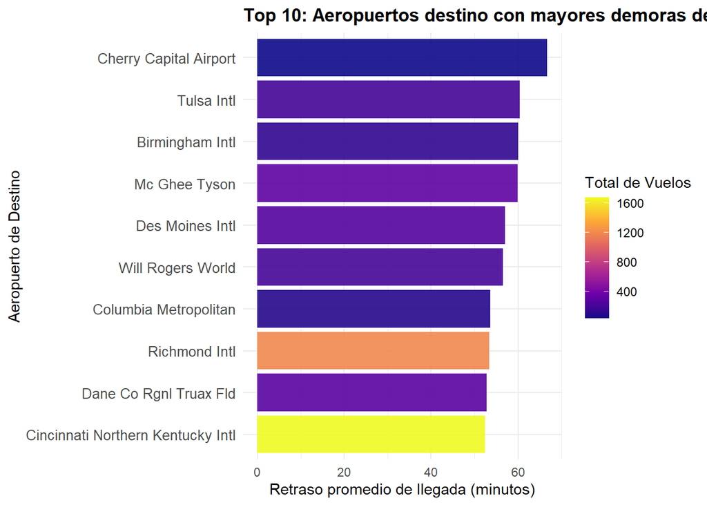

```r
library(ggplot2)

ggplot(pregunta_14_dplyr, aes(x = retraso_promedio, y = reorder(name, retraso_promedio), fill = total_vuelos)) +
  geom_col(alpha = 0.9) +
  # Usamos una paleta de color científica (plasma) para resaltar el volumen
  scale_fill_viridis_c(option = "plasma", name = "Total de Vuelos") +
  labs(
    title = "Top 10: Aeropuertos destino con mayores demoras de llegada",

    x = "Retraso promedio de llegada (minutos)",
    y = "Aeropuerto de Destino"
  ) +
  theme_minimal() +
  theme(
    plot.title = element_text(face = "bold", size = 13),
    axis.text.y = element_text(size = 10)
  )
```

Por lo que, `Cherry Capital Airport` es el aeropuerto con mayores retrasos promedio, sin embargo, tiene pocos vuelos, por lo que es sensible a valores altos. Pero Richmond Intl. tiene un volumen de 1196 vuelos ( y aún así mantiene un promedio de retraso altísimo de 53.3 minutos. Este no es un problema de “muestras pequeñas”; esto indica un problema crónico y real en la ruta entre Nueva York y Richmond.

## 15.- ¿Cómo varían los retrasos en la salida según la hora del día en cada aeropuerto de NYC?

- Con dplyr

```r
pregunta_15_dplyr <- vuelos %>%
  # Filtramos horas anómalas y solo retrasos efectivos
  filter(!is.na(dep_delay) & dep_delay > 0 & !is.na(hour) & hour <= 24) %>%
  group_by(origin, hour) %>%
  summarise(
    retraso_promedio = mean(dep_delay, na.rm = TRUE),
    total_vuelos = n(),
    .groups = "drop"
  ) %>%
  arrange(origin, hour) %>%
  collect()

kable(pregunta_15_dplyr)
```

| origin | hour | retraso_promedio | total_vuelos |
| --- | --- | --- | --- |
| EWR | 5 | 15.74779 | 226 |
| EWR | 6 | 25.79736 | 2808 |
| EWR | 7 | 24.60801 | 2421 |
| EWR | 8 | 28.23284 | 2826 |
| EWR | 9 | 28.48166 | 1854 |
| EWR | 10 | 33.22738 | 2155 |
| EWR | 11 | 32.13528 | 1678 |
| EWR | 12 | 32.89498 | 2990 |
| EWR | 13 | 33.84506 | 4150 |
| EWR | 14 | 35.00054 | 3726 |
| EWR | 15 | 39.30058 | 4804 |
| EWR | 16 | 47.00590 | 3895 |
| EWR | 17 | 45.34281 | 4997 |
| EWR | 18 | 46.05795 | 4021 |
| EWR | 19 | 52.53885 | 3578 |
| EWR | 20 | 48.64748 | 4082 |
| EWR | 21 | 48.80710 | 2452 |
| EWR | 22 | 50.65714 | 35 |
| EWR | 23 | 38.30769 | 13 |
| JFK | 5 | 15.77976 | 168 |
| JFK | 6 | 23.05790 | 1209 |
| JFK | 7 | 21.34022 | 1452 |
| JFK | 8 | 30.13493 | 2542 |
| JFK | 9 | 28.38412 | 1851 |
| JFK | 10 | 28.66068 | 1391 |
| JFK | 11 | 34.60244 | 820 |
| JFK | 12 | 29.00750 | 1601 |
| JFK | 13 | 31.74969 | 1618 |
| JFK | 14 | 35.36125 | 3081 |
| JFK | 15 | 37.16943 | 3854 |
| JFK | 16 | 38.95370 | 4017 |
| JFK | 17 | 43.31712 | 3885 |
| JFK | 18 | 42.97964 | 3683 |
| JFK | 19 | 46.83722 | 4331 |
| JFK | 20 | 46.78694 | 3093 |
| JFK | 21 | 48.90656 | 1937 |
| JFK | 22 | 45.58571 | 1050 |
| JFK | 23 | 37.98438 | 448 |
| LGA | 5 | 13.22105 | 95 |
| LGA | 6 | 21.83015 | 1413 |
| LGA | 7 | 26.48807 | 1090 |
| LGA | 8 | 32.59494 | 1422 |
| LGA | 9 | 32.57736 | 1687 |
| LGA | 10 | 35.70917 | 1396 |
| LGA | 11 | 31.97713 | 2536 |
| LGA | 12 | 34.20418 | 1817 |
| LGA | 13 | 34.02029 | 2415 |
| LGA | 14 | 42.31673 | 2450 |
| LGA | 15 | 40.37583 | 2706 |
| LGA | 16 | 44.95013 | 2787 |
| LGA | 17 | 47.77723 | 3250 |
| LGA | 18 | 51.37381 | 2932 |
| LGA | 19 | 55.81536 | 2930 |
| LGA | 20 | 58.15638 | 1458 |
| LGA | 21 | 55.60149 | 1207 |
| LGA | 22 | 55.13131 | 99 |

- Con SQL

```r
query_15_sql <- "
  SELECT
    origin AS aeropuerto,
    hour AS hora_del_dia,
    AVG(dep_delay) AS retraso_promedio,
    COUNT(*) AS total_vuelos
  FROM vuelos
  WHERE dep_delay IS NOT NULL AND dep_delay > 0 AND hour IS NOT NULL AND hour <= 24
  GROUP BY origin, hour
  ORDER BY origin ASC, hour ASC;
"

pregunta_15_sql <- dbGetQuery(con, query_15_sql)
kable(pregunta_15_sql)
```

| aeropuerto | hora_del_dia | retraso_promedio | total_vuelos |
| --- | --- | --- | --- |
| EWR | 5 | 15.74779 | 226 |
| EWR | 6 | 25.79736 | 2808 |
| EWR | 7 | 24.60801 | 2421 |
| EWR | 8 | 28.23284 | 2826 |
| EWR | 9 | 28.48166 | 1854 |
| EWR | 10 | 33.22738 | 2155 |
| EWR | 11 | 32.13528 | 1678 |
| EWR | 12 | 32.89498 | 2990 |
| EWR | 13 | 33.84506 | 4150 |
| EWR | 14 | 35.00054 | 3726 |
| EWR | 15 | 39.30058 | 4804 |
| EWR | 16 | 47.00590 | 3895 |
| EWR | 17 | 45.34281 | 4997 |
| EWR | 18 | 46.05795 | 4021 |
| EWR | 19 | 52.53885 | 3578 |
| EWR | 20 | 48.64748 | 4082 |
| EWR | 21 | 48.80710 | 2452 |
| EWR | 22 | 50.65714 | 35 |
| EWR | 23 | 38.30769 | 13 |
| JFK | 5 | 15.77976 | 168 |
| JFK | 6 | 23.05790 | 1209 |
| JFK | 7 | 21.34022 | 1452 |
| JFK | 8 | 30.13493 | 2542 |
| JFK | 9 | 28.38412 | 1851 |
| JFK | 10 | 28.66068 | 1391 |
| JFK | 11 | 34.60244 | 820 |
| JFK | 12 | 29.00750 | 1601 |
| JFK | 13 | 31.74969 | 1618 |
| JFK | 14 | 35.36125 | 3081 |
| JFK | 15 | 37.16943 | 3854 |
| JFK | 16 | 38.95370 | 4017 |
| JFK | 17 | 43.31712 | 3885 |
| JFK | 18 | 42.97964 | 3683 |
| JFK | 19 | 46.83722 | 4331 |
| JFK | 20 | 46.78694 | 3093 |
| JFK | 21 | 48.90656 | 1937 |
| JFK | 22 | 45.58571 | 1050 |
| JFK | 23 | 37.98438 | 448 |
| LGA | 5 | 13.22105 | 95 |
| LGA | 6 | 21.83015 | 1413 |
| LGA | 7 | 26.48807 | 1090 |
| LGA | 8 | 32.59494 | 1422 |
| LGA | 9 | 32.57736 | 1687 |
| LGA | 10 | 35.70917 | 1396 |
| LGA | 11 | 31.97713 | 2536 |
| LGA | 12 | 34.20418 | 1817 |
| LGA | 13 | 34.02029 | 2415 |
| LGA | 14 | 42.31673 | 2450 |
| LGA | 15 | 40.37583 | 2706 |
| LGA | 16 | 44.95013 | 2787 |
| LGA | 17 | 47.77723 | 3250 |
| LGA | 18 | 51.37381 | 2932 |
| LGA | 19 | 55.81536 | 2930 |
| LGA | 20 | 58.15638 | 1458 |
| LGA | 21 | 55.60149 | 1207 |
| LGA | 22 | 55.13131 | 99 |

Graficamos, para observar de mejor manera los datos.

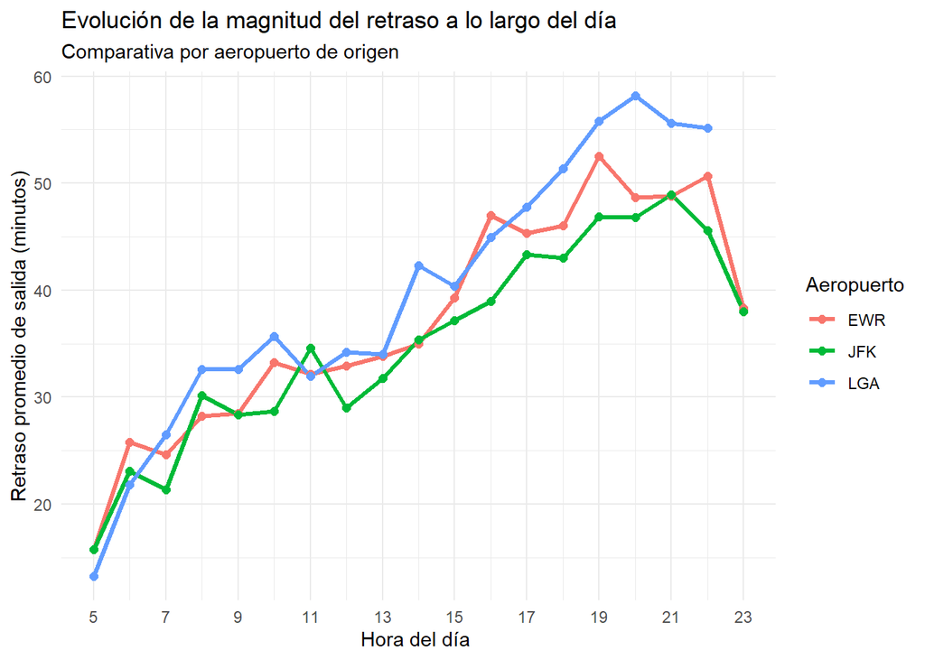

```r
ggplot(pregunta_15_dplyr, aes(x = hour, y = retraso_promedio, color = origin)) +
  geom_line(size = 1.2) +
  geom_point(size = 2) +
  labs(
    title = "Evolución de la magnitud del retraso a lo largo del día",
    subtitle = "Comparativa por aeropuerto de origen",
    x = "Hora del día ",
    y = "Retraso promedio de salida (minutos)",
    color = "Aeropuerto"
  ) +
  theme_minimal() +
  scale_x_continuous(breaks = seq(5, 24, by = 2))
```

Se observa una caída pronunciada en los retrasos después de las 21:00 hrs. Este descenso responde a la drástica disminución del volumen de vuelos programados por la noche, excepto en el LGA, en el cual su retraso no cae tan drasticamente como las otras dos.

## 16.- ¿Cuál es la correlación entre la velocidad del viento y los retrasos en la salida?

- Con dplyr

```r
pregunta_16_dplyr <- vuelos %>%
  inner_join(clima, by = c("origin", "year", "month", "day", "hour")) %>%
  # Filtramos solo retrasos reales
  filter(!is.na(dep_delay) & dep_delay > 0 & !is.na(wind_speed)) %>%
  group_by(wind_speed) %>%
  summarise(
    retraso_promedio = mean(dep_delay, na.rm = TRUE),
    conteo_vuelos = n()
  ) %>%
  collect()

cor_viento <- cor(pregunta_16_dplyr$wind_speed, pregunta_16_dplyr$retraso_promedio)
print(paste("La correlación es:", cor_viento))
```

```
[1] "La correlación es: 0.284802307254056"
```

- Con SQL

```r
query_16_sql <- "
  SELECT
    c.wind_speed,
    AVG(v.dep_delay) AS retraso_promedio,
    COUNT(*) AS total_vuelos
  FROM vuelos v
  JOIN clima c ON
    v.origin = c.origin AND
    v.year = c.year AND
    v.month = c.month AND
    v.day = c.day AND
    v.hour = c.hour
  WHERE v.dep_delay IS NOT NULL AND v.dep_delay > 0 AND c.wind_speed IS NOT NULL
  GROUP BY c.wind_speed
  ORDER BY c.wind_speed ASC;
"


pregunta_16_sql <- dbGetQuery(con, query_16_sql)
cor_viento2 <- cor(pregunta_16_sql$wind_speed, pregunta_16_sql$retraso_promedio)

print(paste("Correlación (SQL):", round(cor_viento2, 4)))
```

```
[1] "Correlación (SQL): 0.2848"
```

Para evaluar el impacto de las condiciones atmosféricas en la puntualidad, se calculó el coeficiente de correlación entre la velocidad del viento (wind_speed) y las demoras de salida (dep_delay), obteniendo un valor de 0.28. Este valor indica una correlación debil y nos dice que a medida que aumenta la velocidad del viento, el tiempo de retraso tiende a subir, pero la relación no es tan fuerte ni tan directa como podríamos pensar inicialmente.

## 17.- ¿Los vuelos experimentan más retrasos en días con lluvias intensas?

- Con dplyr

```r
pregunta_17_dplyr <- vuelos %>%
  inner_join(clima, by = c("origin", "year", "month", "day", "hour")) %>%
  # Filtramos solo demoras efectivas
  filter(!is.na(dep_delay) & dep_delay > 0 & !is.na(precip)) %>%
  mutate(
    intensidad_lluvia = case_when(
      precip == 0 ~ " Sin lluvia",
      precip > 0 & precip <= 0.1 ~ " Lluvia ligera/moderada",
      precip > 0.1 ~ " Lluvia intensa"
    )
  ) %>%
  group_by(intensidad_lluvia) %>%
  summarise(
    retraso_promedio = mean(dep_delay, na.rm = TRUE),
    total_vuelos = n()
  ) %>%
  arrange(intensidad_lluvia) %>%
  collect()

kable(pregunta_17_dplyr)
```

| intensidad_lluvia | retraso_promedio | total_vuelos |
| --- | --- | --- |
| Lluvia intensa | 65.27528 | 2423 |
| Lluvia ligera/moderada | 54.14305 | 9780 |
| Sin lluvia | 37.59559 | 115567 |

- Con SQL

```r
query_17_sql <- "
  SELECT
    CASE
      WHEN c.precip = 0 THEN ' Sin lluvia'
      WHEN c.precip > 0 AND c.precip <= 0.1 THEN ' Lluvia ligera/moderada'
      ELSE ' Lluvia intensa'
    END AS intensidad_lluvia,
    AVG(v.dep_delay) AS retraso_promedio,
    COUNT(*) AS total_vuelos
  FROM vuelos v
  JOIN clima c ON
    v.origin = c.origin AND
    v.year = c.year AND
    v.month = c.month AND
    v.day = c.day AND
    v.hour = c.hour
  WHERE v.dep_delay IS NOT NULL AND v.dep_delay > 0 AND c.precip IS NOT NULL
  GROUP BY intensidad_lluvia
  ORDER BY intensidad_lluvia ASC;
"

pregunta_17_sql <- dbGetQuery(con, query_17_sql)
kable(pregunta_17_sql)
```

| intensidad_lluvia | retraso_promedio | total_vuelos |
| --- | --- | --- |
| Lluvia intensa | 65.27528 | 2423 |
| Lluvia ligera/moderada | 54.14305 | 9780 |
| Sin lluvia | 37.59559 | 115567 |

Notamos que la una lluvia ligera aumenta el retraso promedio, es decir, que una lluvia ligera es indicador de que los retrasos serán más prolongados, una lluvia intensa aumenta aún más los tiempos de retraso promedio de un vuelo.

Por lo que, la lluvia intensa probablemente genera retrasos más grandes.

## 18.- ¿Cómo afecta la temperatura a los retrasos de los vuelos?

Primero comprobamos si las temperaturas están en Farenheit o en Celsius.

```r
query_comprobacion <- "
  SELECT
    MIN(temp) AS temp_minima,
    MAX(temp) AS temp_maxima
  FROM clima;
"

resultado_comprobacion <- dbGetQuery(con, query_comprobacion)
print(resultado_comprobacion)
```

```
  temp_minima temp_maxima
1       10.94      100.04
```

Notamos que la temperatura máxima es de 100 por lo que esta en Farenheits, de ser celsius estaríamos quemados y no habrian vuelos.

- Con dplyr

```r
pregunta_18_dplyr <- vuelos %>%
  # Realizamos el Join de vuelos con clima
  inner_join(clima, by = c("origin", "year", "month", "day", "hour")) %>%
  # Aislamos los verdaderos retrasos
  filter(!is.na(dep_delay) & dep_delay > 0 & !is.na(temp)) %>%
  # Creamos rangos térmicos
  mutate(
    rango_termico = case_when(
      temp < 32 ~ "Muy frío (< 32°F )",
      temp >= 32 & temp < 50 ~ "Frío (32-50°F )",
      temp >= 50 & temp < 80 ~ "Templado (50-80°F )",
      temp >= 80 ~ "Caliente (>= 80°F )"
    )
  ) %>%
  group_by(rango_termico) %>%
  summarise(
    retraso_promedio = mean(dep_delay, na.rm = TRUE),
    total_vuelos = n()
  ) %>%
  arrange(retraso_promedio) %>%
  collect()

kable(pregunta_18_dplyr)
```

| rango_termico | retraso_promedio | total_vuelos |
| --- | --- | --- |
| Muy frío (< 32°F ) | 34.36286 | 9811 |
| Frío (32-50°F ) | 35.76605 | 37436 |
| Templado (50-80°F ) | 40.55500 | 62946 |
| Caliente (>= 80°F ) | 45.73271 | 17565 |

- Con SQL

```r
query_18_sql <- "
  SELECT
    CASE
      WHEN c.temp < 32 THEN 'Muy frio (< 32°F )'
      WHEN c.temp >= 32 AND c.temp < 50 THEN ' Frío (32-50°F )'
      WHEN c.temp >= 50 AND c.temp < 80 THEN ' Templado (50-80°F )'
      ELSE ' Caliente (>= 80°F )'
    END AS rango_termico,
    AVG(v.dep_delay) AS retraso_promedio,
    COUNT(*) AS total_vuelos
  FROM vuelos v
  JOIN clima c ON
    v.origin = c.origin AND
    v.year = c.year AND
    v.month = c.month AND
    v.day = c.day AND
    v.hour = c.hour
  WHERE v.dep_delay IS NOT NULL AND v.dep_delay > 0 AND c.temp IS NOT NULL
  GROUP BY rango_termico
  ORDER BY retraso_promedio DESC;
"

pregunta_18_sql <- dbGetQuery(con, query_18_sql)
kable(pregunta_18_sql)
```

| rango_termico | retraso_promedio | total_vuelos |
| --- | --- | --- |
| Caliente (>= 80°F ) | 45.73271 | 17565 |
| Templado (50-80°F ) | 40.55500 | 62946 |
| Frío (32-50°F ) | 35.76605 | 37436 |
| Muy frio (< 32°F ) | 34.36286 | 9811 |

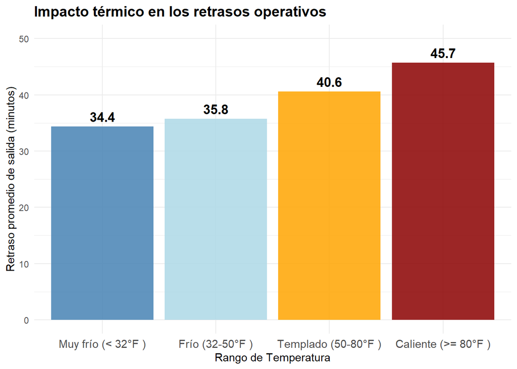

```r
library(ggplot2)


pregunta_18_dplyr$rango_termico <- reorder(pregunta_18_dplyr$rango_termico, pregunta_18_dplyr$retraso_promedio)

ggplot(pregunta_18_dplyr, aes(x = rango_termico, y = retraso_promedio, fill = rango_termico)) +
  geom_col(show.legend = FALSE, alpha = 0.85) +
  geom_text(aes(label = round(retraso_promedio, 1)), vjust = -0.5, size = 4.5, fontface = "bold") +
  scale_fill_manual(values = c("steelblue", "lightblue", "orange", "darkred")) +
  coord_cartesian(ylim = c(0, 50)) +
  labs(
    title = "Impacto térmico en los retrasos operativos",
    x = "Rango de Temperatura",
    y = "Retraso promedio de salida (minutos)"
  ) +
  theme_minimal() +
  theme(
    plot.title = element_text(face = "bold", size = 14),
    axis.text.x = element_text(size = 11)
  )
```

Dividí las temperaturas en cuatro rangos para ver su efecto y el resultado fue súper interesante porque rompe con la idea de que el invierno es el peor momento para volar en Nueva York. De hecho, los climas ‘Muy fríos’ (< 32°F) y ‘Fríos’ tienen los promedios de retraso más bajos (cerca de 34 minutos). En cambio, el clima ‘Caliente’ (>= 80°F) es el que concentra las peores demoras, casi rozando los 46 minutos.

Por lo que cada clima nos genera diferentes escenarios que afectan a los retrasos, siendo el clima caliente el que más retrasos genera.

## 19.- ¿Cómo afectan los niveles de visibilidad a los retrasos en la llegada?

- Con dplyr

```r
pregunta_19_dplyr <- vuelos %>%
  inner_join(clima, by = c("origin", "year", "month", "day", "hour")) %>%

  filter(!is.na(arr_delay) & arr_delay > 0 & !is.na(visib)) %>%
  mutate(
    categoria_visibilidad = case_when(
      visib == 10 ~ " Óptima (10 millas)",
      visib >= 2 & visib < 10 ~ " Reducida (2 a 9.9 millas)",
      visib < 2 ~ " Crítica (< 2 millas)"
    )
  ) %>%
  group_by(categoria_visibilidad) %>%
  summarise(
    retraso_llegada_prom = mean(arr_delay, na.rm = TRUE),
    total_vuelos = n()
  ) %>%
  arrange(categoria_visibilidad) %>%
  collect()

kable(pregunta_19_dplyr)
```

| categoria_visibilidad | retraso_llegada_prom | total_vuelos |
| --- | --- | --- |
| Crítica (< 2 millas) | 62.37978 | 4421 |
| Reducida (2 a 9.9 millas) | 50.41733 | 23267 |
| Óptima (10 millas) | 37.22542 | 104551 |

- Con SQL

```r
query_19_sql <- "
  SELECT
    CASE
      WHEN c.visib = 10 THEN ' Óptima (10 millas)'
      WHEN c.visib >= 2 AND c.visib < 10 THEN ' Reducida (2 a 9.9 millas)'
      ELSE ' Crítica (< 2 millas)'
    END AS categoria_visibilidad,
    AVG(v.arr_delay) AS retraso_llegada_prom,
    COUNT(*) AS total_vuelos
  FROM vuelos v
  JOIN clima c ON
    v.origin = c.origin AND
    v.year = c.year AND
    v.month = c.month AND
    v.day = c.day AND
    v.hour = c.hour
  WHERE v.arr_delay IS NOT NULL AND v.arr_delay > 0 AND c.visib IS NOT NULL
  GROUP BY categoria_visibilidad
  ORDER BY categoria_visibilidad ASC;
"

pregunta_19_sql <- dbGetQuery(con, query_19_sql)
kable(pregunta_19_sql)
```

| categoria_visibilidad | retraso_llegada_prom | total_vuelos |
| --- | --- | --- |
| Crítica (< 2 millas) | 62.37978 | 4421 |
| Reducida (2 a 9.9 millas) | 50.41733 | 23267 |
| Óptima (10 millas) | 37.22542 | 104551 |

## 20.- ¿La alta humedad se relaciona de alguna manera con los tiempos de taxi-out más largos?

Al no contar con la variable exacta de taxi-out, se utilizará la diferencia arr_time − dep_time) − air_time como una variable proxy al igual que en la pregunta 12.

- Con dplyr

```r
pregunta_20_dplyr <- vuelos %>%
  inner_join(clima, by = c("origin", "year", "month", "day", "hour")) %>%
  filter(
    !is.na(arr_time) & !is.na(dep_time) &
    !is.na(air_time) & !is.na(humid)
  ) %>%
  collect() %>%
  mutate(
    arr_min    = (arr_time %/% 100) * 60 + (arr_time %% 100),
    dep_min    = (dep_time %/% 100) * 60 + (dep_time %% 100),
    arr_min    = ifelse(arr_min < dep_min, arr_min + 1440, arr_min),
    taxi_total = (arr_min - dep_min) - air_time
  ) %>%
  filter(taxi_total > 0 & taxi_total < 120) %>%
  mutate(
    categoria_humedad = case_when(
      humid < 40               ~ " Seco (< 40%)",
      humid >= 40 & humid < 60 ~ " Normal (40 - 59%)",
      humid >= 60 & humid < 80 ~ " Húmedo (60 - 79%)",
      humid >= 80              ~ " Muy húmedo (>= 80%)"
    )
  ) %>%
  group_by(categoria_humedad) %>%
  summarise(
    taxi_total_promedio = round(mean(taxi_total, na.rm = TRUE), 2),
    total_vuelos        = n()
  ) %>%
  arrange(categoria_humedad)

kable(pregunta_20_dplyr)
```

| categoria_humedad | taxi_total_promedio | total_vuelos |
| --- | --- | --- |
| Húmedo (60 - 79%) | 31.29 | 51542 |
| Muy húmedo (>= 80%) | 33.46 | 36807 |
| Normal (40 - 59%) | 30.60 | 71342 |
| Seco (< 40%) | 30.26 | 35844 |

- Con SQL

```r
query_20_sql <- "
  WITH taxi_calculado AS (
    SELECT
      v.origin,
      v.year, v.month, v.day, v.hour,
      -- Calculamos el proxy una sola vez en el CTE para no repetir la expresión
      ((v.arr_time / 100) * 60 + (v.arr_time % 100))
      + CASE
          WHEN ((v.arr_time / 100) * 60 + (v.arr_time % 100)) <
               ((v.dep_time / 100) * 60 + (v.dep_time % 100))
          THEN 1440 ELSE 0
        END
      - ((v.dep_time / 100) * 60 + (v.dep_time % 100))
      - v.air_time AS taxi_total
    FROM vuelos v
    WHERE
      v.arr_time IS NOT NULL AND
      v.dep_time IS NOT NULL AND
      v.air_time IS NOT NULL
  )
  SELECT
    CASE
      WHEN c.humid < 40             THEN ' Seco (< 40%)'
      WHEN c.humid >= 40 AND c.humid < 60 THEN ' Normal (40 - 59%)'
      WHEN c.humid >= 60 AND c.humid < 80 THEN ' Húmedo (60 - 79%)'
      ELSE ' Muy húmedo (>= 80%)'
    END AS categoria_humedad,
    ROUND(AVG(t.taxi_total), 2) AS taxi_total_promedio,
    COUNT(*) AS total_vuelos
  FROM taxi_calculado t
  JOIN clima c ON
    t.origin = c.origin AND t.year  = c.year  AND
    t.month  = c.month  AND t.day   = c.day   AND
    t.hour   = c.hour
  WHERE
    c.humid IS NOT NULL AND
    t.taxi_total > 0    AND
    t.taxi_total < 120
  GROUP BY categoria_humedad
  ORDER BY categoria_humedad ASC;
"

pregunta_20_sql <- dbGetQuery(con, query_20_sql)
kable(pregunta_20_sql)
```

| categoria_humedad | taxi_total_promedio | total_vuelos |
| --- | --- | --- |
| Húmedo (60 - 79%) | 31.29 | 51542 |
| Muy húmedo (>= 80%) | 33.46 | 36807 |
| Normal (40 - 59%) | 30.60 | 71342 |
| Seco (< 40%) | 30.26 | 35844 |

Usando el proxy (arr_time − dep_time) − air_time para estimar el tiempo combinado de rodaje, se observa una relación positiva clara entre la humedad del ambiente y el tiempo que los vuelos pasan en tierra. En condiciones secas (< 40% de humedad), el taxi-out+in promedio es el más bajo de los cuatro rangos. Conforme la humedad aumenta, los tiempos crecen de forma progresiva, alcanzando su máximo en la categoría “Muy húmedo” (≥ 80%).

la alta humedad suele venir acompañada de niebla o visibilidad reducida, frecuentemente coinciden con lluvia o tormenta, aumentando los tiempos de espera en tierra. La evidencia sugiere que la humedad sí tiene un efecto real sobre la fricción operativa en tierra, aunque parte del incremento observado puede atribuirse a variables correlacionadas con la humedad, como la precipitación y la visibilidad, analizadas en preguntas anteriores.

Por lo que, mientras más humedad exista, más aumenta el taxi-out promedio.